# Supplementary-material

Fabio Favoretto, Joy Kumagai, Octavio Aburto, Alex Rogers

Last updated 19 enero, 2020

# Premise

In this supplementary, we assume some basic knowledge of the R programming language. If instructions are followed, this should be fully reproducible using R studio. For further comments on the results of this analysis please refer to the main paper, or please find Contacts to get in touch with the authors to report comments, bugs or problems.

A wrangled dataset of all the data mentioned in Table SI and SII is available in the `data` folder.

The R code (v.3.6.1) was written using R-studio IDE (v.1.2.1511), as well as this document, using the following packages that can be installed in R or through R-studio using the following commands:

- `install.packages("tidyverse")`
- `install.packages("readxl")`
- `install.packages("cowplot")`
- `install.packages("ggthemes")`
- `install.packages("broom")`

# Data Sources

Beware that while all data used are open source (except for kelp which source has been removed until the dataset is published), specific permission to reuse and publish them are needed from data providers. Credit for the use of those data should also go to the proper source listed in the table SI and SII.

## Habitat data

To understand habitat area within each Exclusive Economic Zone (EEZ) and the proportion of each habitat that is within an MPA (Marine Protected Area), we collected spatially referenced habitat data for coastal and oceanic ecosystems between February and April 2019. Data for thirty different habitats were found spanning oceanic features digitized from bathymetric data to satellite derived area estimates for many of the coastal habitats. We used a dataset that combined both EEZ area and land that was created by Sala et al., (2018) and intersected it with each habitat using ArcGIS 10.5 Desktop.

Next we calculated the area for each habitat by dissolving the resulting layer by Country and projecting it into the World Cylindrical Equal Area projection, and using the “Calculate Geometry” tool. To extract habitats that are of high conservation importance and the focus of our analysis, we selected habitats that individually contributed less than 0.5% of the cumulative habitat area. Seamounts did not fall under this classification, but due to their ecological importance were combined with guyots in our analysis (Rogers 1994). We used 6 habitats closely associated with the coast and 6 more closely associated with open ocean, for a total of 12 habitats. The table below lists these habitats and datasource used in the analysis. Losses and gains past the dates the data describes were not accounted for.

The February 2019 World Database of Protected Areas (UNEP-WCMC) and IUCN (2019)) was used to calculate the area or the number of reported locations of each habitat inside of an MPA. It needs to be clarified that being inside a MPA does not mean the habitat is protected, since the MPA objective and regulamentation might not involve the habitat at all. However, we consider that being inside an environmentally managed area should provide at least some indirect benefits to the habitat conservation.

The dataset was filtered by MPAs whose status was either designated, inscribed, adopted or established, thus removing not reported and proposed categories. The same methodology for the area calculation within each EEZ was used except the intersection included the filtered MPA dataset. The results were then compiled and compared to ensure that the maximum value of percent protection was 1 for each country.

*Table SI: habitat data type, date and detailed reference*

[output not shown]

## Other data

*Table SII:*

| Variable | Variable name | Description | Source |
| --- | --- | --- | --- |
| Exclusive Economic Zone | eez_area | area of the EEZ for each country | Sala *et al.,* 2018 |
| Marine Protected Area | mpa | World Database of Protected Areas (UNEP-WCMC) and IUCN (2019)) |  |
| Species Biodiversity | biodiversity_points | Extracted value of estimated species diversity | raster from Reygondenau *et al., in press* |
| Pressures on the Marine Environment | pressures | The ecological and social factors that decrease health status | Ocean Health Index: http://www.oceanhealthindex.org/ |
| Gross Domestic Product per capita | gdp_total | total GDP per country (current USD) | World Bank Open data: https://data.worldbank.org/ |
| Amount of area protected | protected | Overlap between protected area and the target habitat | This paper |

Libraries needed:

```r
library(dplyr)
library(ggplot2)
library(readxl)
library(ggpubr)
library(broom)
library(ggthemes)
```

Loading data:

```r
ecosocial <- read_excel("data/BP-10-Dataset.xlsx", sheet = "ecosocial")
```

First of we analysed some relationship with the ecosocial data used.

Human Pressure *vs* Species Biodiversity model

```r
tidy(lm(pressures_spp~biodiversity_points, data=ecosocial))
```

| term | estimate | std.error | statistic | p.value |
| --- | --- | --- | --- | --- |
| (Intercept) | 27.94509204 | 1.600308351 | 17.46232 | 1.977197e-40 |
| biodiversity_points | 0.03243653 | 0.005468282 | 5.93176 | 1.526714e-08 |

% MPA/EEZ *vs* % of World GDP model

```r
ecosocial2 <- ecosocial %>%
        select(country, eez_area, mpa, gdp_tot) %>%
        na.omit() %>%
        mutate(percent_GDP = (gdp_tot/max(gdp_tot))*100) %>%
        mutate(percent_MPA = (mpa/eez_area)*100)

tidy(lm(percent_MPA ~ percent_GDP, data=ecosocial2))
```

| term | estimate | std.error | statistic | p.value |
| --- | --- | --- | --- | --- |
| (Intercept) | 9.5595649 | 1.6668579 | 5.735081 | 4.86769e-08 |
| percent_GDP | 0.3746134 | 0.1741082 | 2.151613 | 3.29567e-02 |

Species Biodiversity *vs* % MPA/EEZ model

```r
ecosocial3 <- ecosocial %>%
        select(country, eez_area, mpa, gdp_tot, biodiversity_points) %>%
        na.omit() %>%
        mutate(percent_MPA = (mpa/eez_area)*100)

tidy(lm(biodiversity_points ~ percent_MPA, data=ecosocial3))
```

| term | estimate | std.error | statistic | p.value |
| --- | --- | --- | --- | --- |
| (Intercept) | 2.722317e+02 | 13.4290483 | 20.271854996 | 6.851806e-44 |
| percent_MPA | 6.883281e-03 | 0.7806563 | 0.008817299 | 9.929772e-01 |

To reproduce the scatterplots relating Biodiversity, protection and GDP one can use the following code:

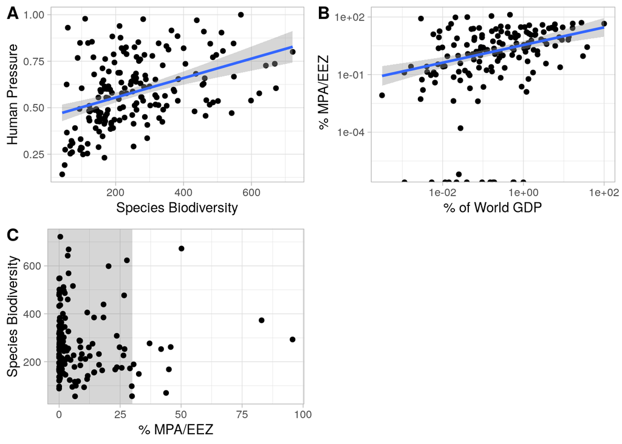

```r
pA <- ecosocial %>%
      select(country, eez_area, mpa, pressures_spp, biodiversity_points) %>%
      na.omit() %>%
      mutate(pressures_spp = pressures_spp/max(pressures_spp)) %>%
      ggplot(aes(x=biodiversity_points, y=pressures_spp)) +
      geom_point() +
      geom_smooth(method='lm',formula=y~x) +
      theme_light() +
      #annotate("text", x = 50, y = 1, label = "A", size=5 ,fontface="bold") +
      labs(x="Species Biodiversity", y="Human Pressure")

pB <- ecosocial2 %>%
   ggplot(aes(x=percent_GDP, y=percent_MPA)) +
   scale_y_continuous(trans = "log10") +
   scale_x_continuous(trans = 'log10') +
   geom_point() +
   geom_smooth(method='lm',formula=y~x) +
   theme_light() +
   labs(x="% of World GDP", y=" % MPA/EEZ")

target <- data.frame(x=c(-Inf,-Inf,30, 30), y=c(-Inf,Inf ,Inf, -Inf), t=c('b', 'b', 'b','b'))

pC <- ecosocial %>%
   select(country, eez_area, mpa, gdp_tot, biodiversity_points) %>%
   na.omit() %>%
   mutate(percent_MPA = (mpa/eez_area)*100) %>%
   ggplot(aes(x=percent_MPA, y=biodiversity_points)) +
   geom_polygon(data=target, mapping=aes(x=x, y=y, group=t), alpha=0.2) +
   geom_point() +
   theme_light() +
   labs(x="% MPA/EEZ", y="Species Biodiversity")

cowplot::plot_grid(pA, pB, pC, labels="AUTO")
```

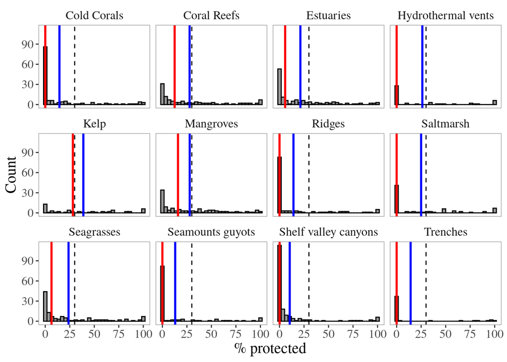

```r
dataset <- read_excel("data/BP-10-Dataset.xlsx", sheet = "protected_areas")


dataset %>%
        filter(Area > 0) %>%
        mutate(pp = (Protected/Area)*100) %>%
        mutate(pp_to_EEZ = (Protected/EEZ_area)*100) %>%
        mutate(relative_to_EEZ = (Area/EEZ_area)*100) %>%
        group_by(Habitat) %>%
        mutate(world_hab_area = sum(Area)) %>%
        ungroup() %>%
        mutate(relative_area_to_world = ((Area/world_hab_area)*100)) %>%
        mutate_if(is.numeric, round, digits = 2) %>%
        select(Habitat, Country, pp) %>%
        group_by(Habitat) %>%
        mutate(mean_pp = mean(pp),
               median_pp = median(pp)) %>%
        ungroup() %>%
        mutate(Habitat = factor(.$Habitat, labels=c("Cold Corals", "Coral Reefs",
                                                          "Estuaries", "Hydrothermal vents",
                                                          "Kelp", "Mangroves", "Ridges",
                                                          "Saltmarsh", "Seagrasses",
                                                          "Seamounts guyots", "Shelf valley canyons",
                                                          "Trenches"))) %>%
        ggplot(aes(x=pp))+
        geom_histogram(fill="grey60", col="black")+
        geom_vline(aes(xintercept=mean_pp), col="blue", size=1)+
        geom_vline(aes(xintercept=median_pp), col="red", size=1)+
        geom_vline(aes(xintercept=30), col="black", linetype="dashed")+
        labs(x= "% protected", y="Count")+
        facet_wrap(~Habitat)+
        theme_tufte()+
        theme(text = element_text(size = 15),
              panel.border = element_rect(fill = NA, colour = "grey60"))
```

# References

Sala, E., Mayorga, J., Costello, C., Kroodsma, D., Palomares, M. L. D., Pauly, D., […] Zeller, D. (2018). The economics of fishing the high seas. Science Advances, 4(6), eaat2504. https://doi.org/10.1126/sciadv.aat2504

## Habitat data references from the table

- Estuaries: Alder J (2003). Putting the coast in the “Sea Around Us”. The Sea Around Us Newsletter 15: 1-2. URL: http://seaaroundus.org/newsletter/Issue15.pdf; http://data.unep-wcmc.org/datasets/23 (version 2.0)
- Mangroves: Giri, C., E. Ochieng, L. L. Tieszen, Z. Zhu, A. Singh, T. Loveland, J. Masek, and N. Duke. (2011). “Status and Distribution of Mangrove Forests of the World Using Earth Observation Satellite Data: Status and Distributions of Global Mangroves.” Global Ecology and Biogeography 20 (1): 154–59. https://doi.org/10.1111/j.1466-8238.2010.00584.x.
- Saltmarsh: Mcowen C, Weatherdon LV, Bochove J, Sullivan E, Blyth S, Zockler C, Stanwell-Smith D, Kingston N, Martin CS, Spalding M, Fletcher S (2017). A global map of saltmarshes. Biodiversity Data Journal 5: e11764. Paper DOI: https://doi.org/10.3897/BDJ.5.e11764; Data URL: http://data.unep-wcmc.org/datasets/43 (v.6)
- Seagrasses:UNEP-WCMC, Short FT (2018). Global distribution of seagrasses (version 6.0). Sixth update to the data layer used in Green and Short (2003). Cambridge (UK): UN Environment World Conservation Monitoring Centre. URL: http://data.unep-wcmc.org/datasets/7
- Coral Reefs: UNEP-WCMC, WorldFish Centre, WRI, TNC (2018). Global distribution of warm-water coral reefs, compiled from multiple sources including the Millennium Coral Reef Mapping Project. Version 4.0. Includes contributions from IMaRS-USF and IRD (2005), IMaRS-USF (2005) and Spalding et al. (2001). Cambridge (UK): UN Environment World Conservation Monitoring Centre. URL: http://data.unep-wcmc.org/datasets/1
- Kelp: Jorge Assis (submitted for publication)
- Coldcorals: Freiwald A, Rogers A, Hall-Spencer J, Guinotte JM, Davies AJ, Yesson C, Martin CS, Weatherdon LV (2017). Global distribution of cold-water corals (version 5.0). Fifth update to the dataset in Freiwald et al. (2004) by UNEP-WCMC, in collaboration with Andre Freiwald and John Guinotte. Cambridge (UK): UN Environment World Conservation Monitoring Centre. URL: http://data.unep-wcmc.org/datasets/3
- Sills-Rift Valleys: Harris, P. T., Macmillan-Lawler, M., Rupp, J., & Baker, E. K. (2014). Geomorphology of the oceans. Marine Geology, 352, 4–24. https://doi.org/10.1016/j.margeo.2014.01.011 Hydrothermal vents: Beaulieu, S.E., Szafranski, K. (2018) InterRidge Global Database of Active Submarine Hydrothermal Vent Fields, Version 3.4. World Wide Web electronic publication available from http://vents-data.interridge.org Accessed 2019-02-20.

# Contacts

- Fabio Favoretto: favoretto.fabio@gmail.com
- Joy Kumagai: jkumagai96@gmail.com
- Octavio Aburto: maburto@ucsd.edu